[figure not shown]

# **Predicting Compressive Strength of Concrete**

**Featurization, Model Selection and Tuning Tutorial**

```python
#importing libraries
import numpy as np
import pandas as pd
import matplotlib.pyplot as plt
import seaborn as sns
import itertools
%matplotlib inline
```

```python
from sklearn.preprocessing import StandardScaler
#Import Sklearn package's data splitting function which is based on random function
from sklearn.model_selection import train_test_split
# Import Linear Regression, Ridge and Lasso machine learning library
from sklearn.linear_model import LinearRegression, Ridge, Lasso
# Import KNN Regressor machine learning library
from sklearn.neighbors import KNeighborsRegressor
# Import Decision Tree Regressor machine learning library
from sklearn.tree import DecisionTreeRegressor
# Import ensemble machine learning library
from sklearn.ensemble import (RandomForestRegressor, GradientBoostingRegressor,AdaBoostRegressor,BaggingRegressor)
# Import support vector regressor machine learning library
from sklearn.svm import SVR
#Import the metrics
from sklearn import metrics
#Import the Voting regressor for Ensemble
from sklearn.ensemble import VotingRegressor
# Import stats from scipy
from scipy import stats
# Import zscore for scaling
from scipy.stats import zscore
#importing the metrics
from sklearn.metrics import mean_squared_error,mean_absolute_error,r2_score
#importing the K fold
from sklearn.model_selection import KFold
#importing the cross validation score
from sklearn.model_selection import cross_val_score
#importing the preprocessing library
from sklearn import preprocessing
# importing the Polynomial features
from sklearn.preprocessing import PolynomialFeatures
#importing kmeans clustering library
from sklearn.cluster import KMeans
from sklearn.utils import resample
```

```python
import warnings
warnings.filterwarnings('ignore')
```

```python
# from pyforest import*
# lazy_imports()
```

```python
df=pd.read_csv("compresive_strength_concrete 2.csv")
```

```python
df.head()
```

|  | Cement (component 1)(kg in a m^3 mixture) | Blast Furnace Slag (component 2)(kg in a m^3 mixture) | Fly Ash (component 3)(kg in a m^3 mixture) | Water (component 4)(kg in a m^3 mixture) | Superplasticizer (component 5)(kg in a m^3 mixture) | Coarse Aggregate (component 6)(kg in a m^3 mixture) | Fine Aggregate (component 7)(kg in a m^3 mixture) | Age (day) | Concrete compressive strength(MPa, megapascals) |
| --- | --- | --- | --- | --- | --- | --- | --- | --- | --- |
| 0 | 540.0 | 0.0 | 0.0 | 162.0 | 2.5 | 1040.0 | 676.0 | 28 | 79.99 |
| 1 | 540.0 | 0.0 | 0.0 | 162.0 | 2.5 | 1055.0 | 676.0 | 28 | 61.89 |
| 2 | 332.5 | 142.5 | 0.0 | 228.0 | 0.0 | 932.0 | 594.0 | 270 | 40.27 |
| 3 | 332.5 | 142.5 | 0.0 | 228.0 | 0.0 | 932.0 | 594.0 | 365 | 41.05 |
| 4 | 198.6 | 132.4 | 0.0 | 192.0 | 0.0 | 978.4 | 825.5 | 360 | 44.30 |

Observation

1. It shows that there are eight independent variables ( cement, slag, ash, water, superplastic, coarseagg, fineagg, age) and one dependent variable (strength).
2. All the records are numeric.

```python
df = df.rename(columns={'Cement (component 1)(kg in a m^3 mixture)':"cement",
       'Blast Furnace Slag (component 2)(kg in a m^3 mixture)':"slag",
       'Fly Ash (component 3)(kg in a m^3 mixture)':"ash",
       'Water  (component 4)(kg in a m^3 mixture)':"water",
       'Superplasticizer (component 5)(kg in a m^3 mixture)':"superplastic",
       'Coarse Aggregate  (component 6)(kg in a m^3 mixture)':"coarseagg",
       'Fine Aggregate (component 7)(kg in a m^3 mixture)':"fineagg", 'Age (day)':"age",
       'Concrete compressive strength(MPa, megapascals) ':"strength"})
```

```python
df.head()
```

|  | cement | slag | ash | water | superplastic | coarseagg | fineagg | age | strength |
| --- | --- | --- | --- | --- | --- | --- | --- | --- | --- |
| 0 | 540.0 | 0.0 | 0.0 | 162.0 | 2.5 | 1040.0 | 676.0 | 28 | 79.99 |
| 1 | 540.0 | 0.0 | 0.0 | 162.0 | 2.5 | 1055.0 | 676.0 | 28 | 61.89 |
| 2 | 332.5 | 142.5 | 0.0 | 228.0 | 0.0 | 932.0 | 594.0 | 270 | 40.27 |
| 3 | 332.5 | 142.5 | 0.0 | 228.0 | 0.0 | 932.0 | 594.0 | 365 | 41.05 |
| 4 | 198.6 | 132.4 | 0.0 | 192.0 | 0.0 | 978.4 | 825.5 | 360 | 44.30 |

```python
df.dtypes
```

```
cement          float64
slag            float64
ash             float64
water           float64
superplastic    float64
coarseagg       float64
fineagg         float64
age               int64
strength        float64
dtype: object
```

```python
df.shape
```

```
(1030, 9)
```

```python
#Checking for missing values


df.isnull().sum()
```

```
cement          0
slag            0
ash             0
water           0
superplastic    0
coarseagg       0
fineagg         0
age             0
strength        0
dtype: int64
```

```python
df.describe().T
```

|  | count | mean | std | min | 25% | 50% | 75% | max |
| --- | --- | --- | --- | --- | --- | --- | --- | --- |
| cement | 1030.0 | 281.167864 | 104.506364 | 102.00 | 192.375 | 272.900 | 350.000 | 540.0 |
| slag | 1030.0 | 73.895825 | 86.279342 | 0.00 | 0.000 | 22.000 | 142.950 | 359.4 |
| ash | 1030.0 | 54.188350 | 63.997004 | 0.00 | 0.000 | 0.000 | 118.300 | 200.1 |
| water | 1030.0 | 181.567282 | 21.354219 | 121.80 | 164.900 | 185.000 | 192.000 | 247.0 |
| superplastic | 1030.0 | 6.204660 | 5.973841 | 0.00 | 0.000 | 6.400 | 10.200 | 32.2 |
| coarseagg | 1030.0 | 972.918932 | 77.753954 | 801.00 | 932.000 | 968.000 | 1029.400 | 1145.0 |
| fineagg | 1030.0 | 773.580485 | 80.175980 | 594.00 | 730.950 | 779.500 | 824.000 | 992.6 |
| age | 1030.0 | 45.662136 | 63.169912 | 1.00 | 7.000 | 28.000 | 56.000 | 365.0 |
| strength | 1030.0 | 35.817961 | 16.705742 | 2.33 | 23.710 | 34.445 | 46.135 | 82.6 |

## Exploratory Data Analysis

**CEMENT**

```python
#Quartiles
from scipy import stats

Q1=df['cement'].quantile(q=0.25)
Q3=df['cement'].quantile(q=0.75)
print('1st Quartile (Q1) is: ', Q1)
print('3st Quartile (Q3) is: ', Q3)
print('Interquartile range (IQR) is ', stats.iqr(df['cement']))
```

```
1st Quartile (Q1) is:  192.375
3st Quartile (Q3) is:  350.0
Interquartile range (IQR) is  157.625
```

```python
#Outlier detection from Interquartile range (IQR) in original data


L_outliers=Q1-1.5*(Q3-Q1)
U_outliers=Q3+1.5*(Q3-Q1)
print('Lower outliers limit in cement: ', L_outliers)
print('Upper outliers limit in cement: ', U_outliers)
```

```
Lower outliers limit in cement:  -44.0625
Upper outliers limit in cement:  586.4375
```

```python
#Checking for presence of outliers with the upper and lower limits

print('Number of outliers in cement upper : ', df[df['cement']>586.4375]['cement'].count())
print('Number of outliers in cement lower : ',df[df['cement']<-44.0625]['cement'].count())



# print('% of Outlier in cement upper: ',round(df[df['cement']>586.4375]['cement'].count()*100/len(df)), '%')
# print('% of Outlier in cement lower: ',round(df[df['cement']<-44.0625]['cement'].count()*100/len(df)), '%')
```

```
Number of outliers in cement upper :  0
Number of outliers in cement lower :  0
```

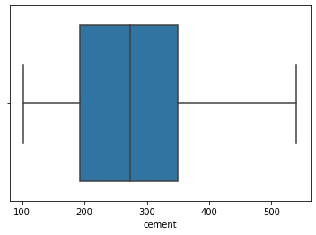

```python
#Distribution of CEMENT

sns.boxplot(x='cement',data=df,orient='h')
```

[figure not shown]

```python
#distplot
plt.figure(figsize=(10,8))
sns.distplot(df['ash']).set_title("Ash")
```

## Water

**From the describe function above:**

Minimum water: 121.8

Maximum water: 247.0

Mean value: 181.56728155339803

Median value: 185.0

Standard deviation: 21.354218565032525

Null values: 0

```python
#Quartiles
w_Q1=df['water'].quantile(q=0.25)
w_Q3=df['water'].quantile(q=0.75)
print('1st Quartile (Q1) is: ', w_Q1)
print('3rd Quartile (Q3) is: ', w_Q3)
print('Interquartile range (IQR) is ', stats.iqr(df['water']))
```

```
1st Quartile (Q1) is:  164.9
3rd Quartile (Q3) is:  192.0
Interquartile range (IQR) is  27.099999999999994
```

```python
#Outlier detection from Interquartile range (IQR) in original data

WL_outliers=w_Q1-1.5*(w_Q3-w_Q1)
WU_outliers=w_Q3+1.5*(w_Q3-w_Q1)
print('Lower outliers in water: ', WL_outliers)
print('Upper outliers in water: ', WU_outliers)
```

```
Lower outliers in water:  124.25000000000001
Upper outliers in water:  232.64999999999998
```

```python
#Checking for presence of outliers with the upper and lower limits


print('Number of outliers in water upper : ', df[df['water']>232.65]['water'].count())
print('Number of outliers in water lower : ', df[df['water']<124.25]['water'].count())


# print('% of Outlier in water upper: ',round(df[df['water']>232.65]['water'].count()*100/len(df)), '%')
# print('% of Outlier in water lower: ',round(df[df['water']<124.25]['water'].count()*100/len(df)), '%')
```

```
Number of outliers in water upper :  4
Number of outliers in water lower :  5
```

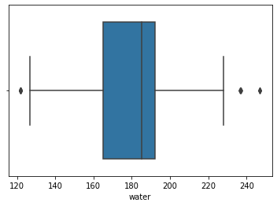

```python
#Distribution of WATER

sns.boxplot(x='water',data=df,orient='h')
```

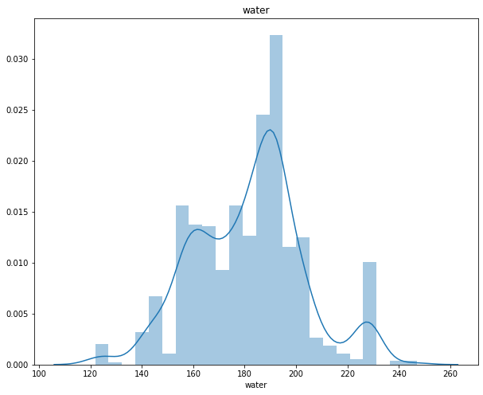

```python
plt.figure(figsize=(10,8))
sns.distplot(df['water']).set_title("water")
```

## Slag

1st Quartile (Q1) is: 0.0

3st Quartile (Q3) is: 142.95

Interquartile range (IQR) is 142.95

```python
Q1=df['slag'].quantile(q=0.25)
Q3=df['slag'].quantile(q=0.75)
```

```python
L_outliers=Q1-1.5*(Q3-Q1)
U_outliers=Q3+1.5*(Q3-Q1)
print('Lower outliers in slag: ', L_outliers)
print('Upper outliers in slag: ', U_outliers)
```

```
Lower outliers in slag:  -214.42499999999998
Upper outliers in slag:  357.375
```

```python
print('Number of outliers in slag upper : ', df[df['slag']>357.375]['slag'].count())
print('Number of outliers in slag lower : ', df[df['slag']<-214.425]['slag'].count())



# print('% of Outlier in slag upper: ',round(df[df['slag']>357.375]['slag'].count()*100/len(df)), '%')
# print('% of Outlier in slag lower: ',round(df[df['slag']<-214.425]['slag'].count()*100/len(df)), '%')
```

```
Number of outliers in slag upper :  2
Number of outliers in slag lower :  0
```

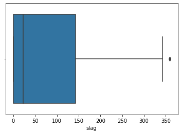

```python
#Distribution of SLAG

sns.boxplot(x='slag',data=df,orient='h')
```

# Age

Minimum age: 1

Maximum age: 365

Mean value: 45.662135922330094

Median value: 28.0

Standard deviation: 63.169911581033155

Null values: False

```python
Q1=df['age'].quantile(q=0.25)
Q3=df['age'].quantile(q=0.75)
```

```python
L_outliers=Q1-1.5*(Q3-Q1)
U_outliers=Q3+1.5*(Q3-Q1)
print('Lower outliers in age: ', L_outliers)
print('Upper outliers in age: ', U_outliers)
```

```
Lower outliers in age:  -66.5
Upper outliers in age:  129.5
```

```python
print('Number of outliers in age upper : ', df[df['age']> 129.5]['age'].count())
print('Number of outliers in age lower : ', df[df['age']< -66.5]['age'].count())

# print('% of Outlier in slag upper: ',round(df[df['age']>357.375]['age'].count()*100/len(df)), '%')
# print('% of Outlier in slag lower: ',round(df[df['age']<-214.425]['age'].count()*100/len(df)), '%')
```

```
Number of outliers in age upper :  59
Number of outliers in age lower :  0
```

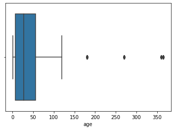

```python
#Distribution of AGE

sns.boxplot(x='age',data=df,orient='h')
```

## Ash

Minimum ash: 0.0

Maximum ash: 200.1

Mean value: 54.18834951456309

Median value: 0.0

Standard deviation: 63.99700415268812

```python
Q1=df['ash'].quantile(q=0.25)
Q3=df['ash'].quantile(q=0.75)
```

```python
L_outliers=Q1-1.5*(Q3-Q1)
U_outliers=Q3+1.5*(Q3-Q1)
print('Lower outliers in ash: ', L_outliers)
print('Upper outliers in ash: ', U_outliers)
```

```
Lower outliers in ash:  -177.45
Upper outliers in ash:  295.75
```

```python
print('Number of outliers in ash upper : ', df[df['ash']>295.75]['ash'].count())
print('Number of outliers in ash lower : ', df[df['ash']<-177.45]['ash'].count())

# print('% of Outlier in slag upper: ',round(df[df['ash']>357.375]['ash'].count()*100/len(df)), '%')
# print('% of Outlier in slag lower: ',round(df[df['ash']<-214.425]['ash'].count()*100/len(df)), '%')
```

```
Number of outliers in ash upper :  0
Number of outliers in ash lower :  0
```

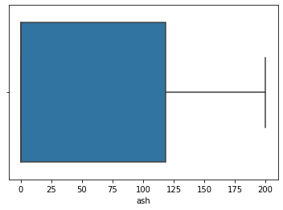

```python
#Distribution of ASH

sns.boxplot(x='ash',data=df,orient='h')
```

## MultiVariate Analysis

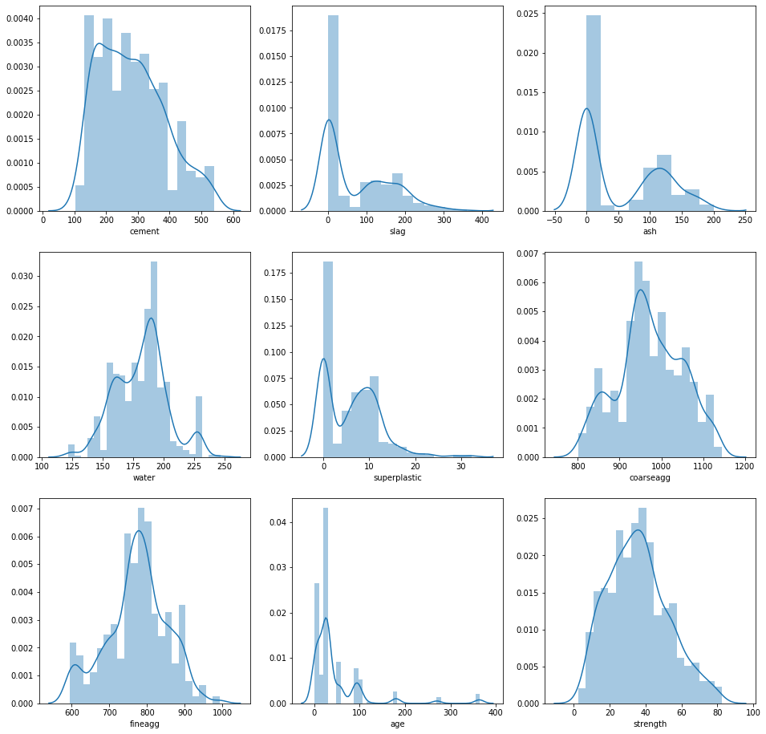

```python
# Distplot
fig, ax2 = plt.subplots(3, 3, figsize=(16, 16))
sns.distplot(df['cement'],ax=ax2[0][0])
sns.distplot(df['slag'],ax=ax2[0][1])
sns.distplot(df['ash'],ax=ax2[0][2])
sns.distplot(df['water'],ax=ax2[1][0])
sns.distplot(df['superplastic'],ax=ax2[1][1])
sns.distplot(df['coarseagg'],ax=ax2[1][2])
sns.distplot(df['fineagg'],ax=ax2[2][0])
sns.distplot(df['age'],ax=ax2[2][1])
sns.distplot(df['strength'],ax=ax2[2][2])
```

**Observation**

**We can see observe that :**

cement is almost normal.

slag has three gausssians and rightly skewed.

ash has two gaussians and rightly skewed.

water has three guassians and slighly left skewed.

superplastic has two gaussians and rightly skewed.

coarseagg has three guassians and almost normal.

fineagg has almost two guassians and looks like normal.

age has multiple guassians and rightly skewed.

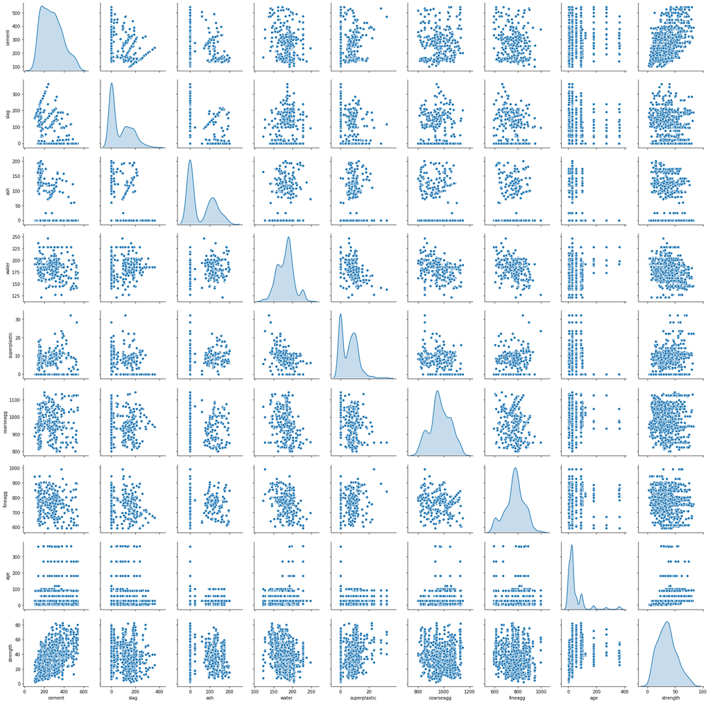

```python
## pairplot- plot density curve instead of histogram in diagonal

sns.pairplot(df, diag_kind='kde')
```

# Correlation between variables

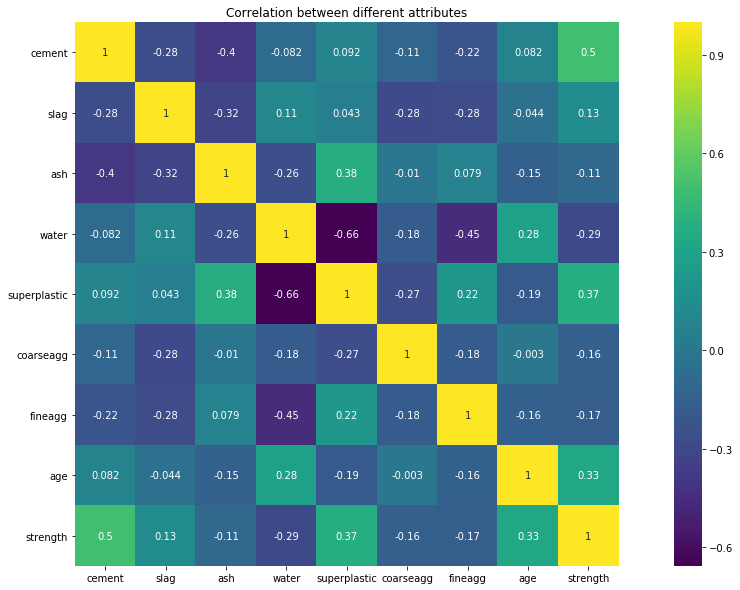

```python
plt.figure(figsize=(20,10))

sns.heatmap(df.corr(), vmax=1, square=True, annot=True,cmap='viridis')
plt.title('Correlation between different attributes')
plt.show()
```

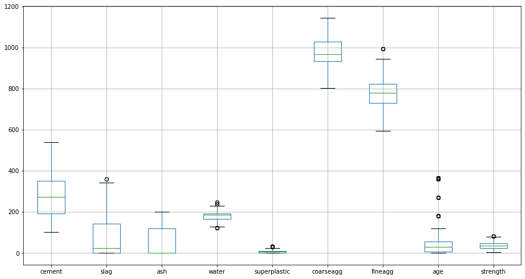

```python
df.boxplot(figsize=(15,8))
```

## Checking for outliers

```python
print('Outliers in cement: ',df[((df.cement - df.cement.mean()) / df.cement.std()).abs() >3]['cement'].count())
print('Outliers in slag: ',df[((df.slag - df.slag.mean()) / df.slag.std()).abs() >3]['slag'].count())
print('Outliers in ash: ',df[((df.ash - df.ash.mean()) /df.ash.std()).abs() >3]['ash'].count())
print('Outliers in water: ',df[((df.water - df.water.mean()) / df.water.std()).abs() >3]['water'].count())
print('Outliers in superplastic: ',df[((df.superplastic -df.superplastic.mean()) /df.superplastic.std()).abs() >3]['superplastic'].count())
print('Outliers in coarseagg: ',df[((df.coarseagg - df.coarseagg.mean()) /df.coarseagg.std()).abs() >3]['coarseagg'].count())
print('Outliers in fineagg: ',df[((df.fineagg - df.fineagg.mean()) /df.fineagg.std()).abs() >3]['fineagg'].count())
print('Outliers in age: ',df[((df.age -df.age.mean()) /df.age.std()).abs() >3]['age'].count())
```

```
Outliers in cement:  0
Outliers in slag:  4
Outliers in ash:  0
Outliers in water:  2
Outliers in superplastic:  10
Outliers in coarseagg:  0
Outliers in fineagg:  0
Outliers in age:  33
```

## Replacing the outliers by median

```python
for cols in df.columns[:-1]:
    Q1 = df[cols].quantile(0.25)
    Q3 = df[cols].quantile(0.75)
    iqr = Q3 - Q1

    low = Q1-1.5*iqr
    high = Q3+1.5*iqr
    df.loc[(df[cols] < low) | (df[cols] > high), cols] = df[cols].median()
```

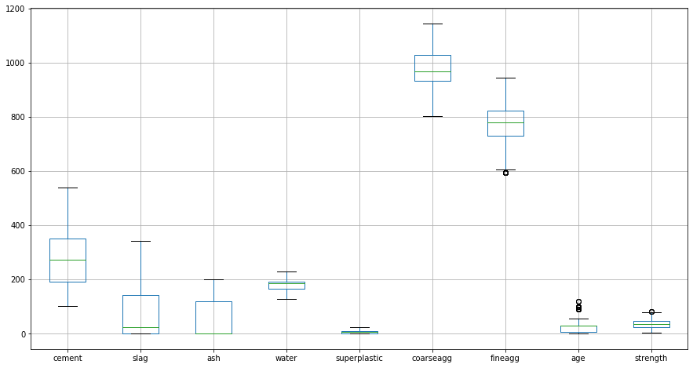

```python
df.boxplot(figsize=(15,8))
```

# Feature Engineering and Model Building

```python
df.head()
```

|  | cement | slag | ash | water | superplastic | coarseagg | fineagg | age | strength |
| --- | --- | --- | --- | --- | --- | --- | --- | --- | --- |
| 0 | 540.0 | 0.0 | 0.0 | 162.0 | 2.5 | 1040.0 | 676.0 | 28.0 | 79.99 |
| 1 | 540.0 | 0.0 | 0.0 | 162.0 | 2.5 | 1055.0 | 676.0 | 28.0 | 61.89 |
| 2 | 332.5 | 142.5 | 0.0 | 228.0 | 0.0 | 932.0 | 594.0 | 28.0 | 40.27 |
| 3 | 332.5 | 142.5 | 0.0 | 228.0 | 0.0 | 932.0 | 594.0 | 28.0 | 41.05 |
| 4 | 198.6 | 132.4 | 0.0 | 192.0 | 0.0 | 978.4 | 825.5 | 28.0 | 44.30 |

```python
#Splitting the data into independent and dependent attributes

#independent and dependent variables
X=df.drop('strength',axis=1)
y =df['strength']
```

```python
from scipy.stats import zscore

Xscaled =X.apply(zscore)
Xscaled_df=pd.DataFrame(Xscaled,columns=df.columns)
```

```python
X_train, X_test, y_train, y_test = train_test_split(Xscaled,y, test_size = 0.3, random_state = 1)
```

## Building Different Models

### Random Forest

```python
model=RandomForestRegressor()
model.fit(X_train, y_train)
```

```
RandomForestRegressor(bootstrap=True, ccp_alpha=0.0, criterion='mse',
                      max_depth=None, max_features='auto', max_leaf_nodes=None,
                      max_samples=None, min_impurity_decrease=0.0,
                      min_impurity_split=None, min_samples_leaf=1,
                      min_samples_split=2, min_weight_fraction_leaf=0.0,
                      n_estimators=100, n_jobs=None, oob_score=False,
                      random_state=None, verbose=0, warm_start=False)
```

```python
y_pred = model.predict(X_test)
```

```python
#Model Performance on Training Data

model.score(X_train,y_train)
```

```
0.9814998330934507
```

```python
#Model Performance on Testing Data

model.score(X_test,y_test)
```

```
0.8774293120770974
```

```python
acc_R=metrics.r2_score(y_test, y_pred)
acc_R
```

```
0.8774293120770974
```

```python
metrics.mean_squared_error(y_test, y_pred)
```

```
32.12665969261957
```

```python
#Store the accuracy results for each model in a dataframe for final comparison
results_1 = pd.DataFrame({'Algorithm':['Random Forest'], 'accuracy': acc_R},index={'1'})
results = results_1[['Algorithm', 'accuracy']]
results
```

|  | Algorithm | accuracy |
| --- | --- | --- |
| 1 | Random Forest | 0.877429 |

# **KFold cross validation**

```python
k = 20

kfold = KFold(n_splits=k, random_state=70) #you can ignore the random state
K_results = cross_val_score(model,X, y, cv=kfold)
accuracy=np.mean(abs(K_results))
accuracy
```

```
0.766505326767278
```

```python
K_results
```

```
array([0.66290746, 0.82739857, 0.40373914, 0.9643773 , 0.77261027,
       0.85026834, 0.64646275, 0.69739475, 0.41984508, 0.543686  ,
       0.79445844, 0.65066163, 0.88137439, 0.84695171, 0.85901647,
       0.83229109, 0.89445695, 0.95380523, 0.88116131, 0.94723966])
```

```python
#Store the accuracy results for each model in a dataframe for final comparison
random_re = pd.DataFrame({'Algorithm':['Random Forest Regressor k_fold'], 'accuracy': [accuracy]},index={'2'})
results = pd.concat([results, random_re])
results = results[['Algorithm', 'accuracy']]
results
```

|  | Algorithm | accuracy |
| --- | --- | --- |
| 1 | Random Forest | 0.877429 |
| 2 | Random Forest Regressor k_fold | 0.766505 |

## Gradient Boosting Regressor

```python
model=GradientBoostingRegressor()
model.fit(X_train, y_train)
```

```
GradientBoostingRegressor(alpha=0.9, ccp_alpha=0.0, criterion='friedman_mse',
                          init=None, learning_rate=0.1, loss='ls', max_depth=3,
                          max_features=None, max_leaf_nodes=None,
                          min_impurity_decrease=0.0, min_impurity_split=None,
                          min_samples_leaf=1, min_samples_split=2,
                          min_weight_fraction_leaf=0.0, n_estimators=100,
                          n_iter_no_change=None, presort='deprecated',
                          random_state=None, subsample=1.0, tol=0.0001,
                          validation_fraction=0.1, verbose=0, warm_start=False)
```

```python
y_pred = model.predict(X_test)
```

```python
model.score(X_train,y_train)
```

```
0.947736861039059
```

```python
aac_G=metrics.r2_score(y_test, y_pred)
aac_G
```

```
0.8803517664041065
```

```python
model.score(X_test,y_test)
```

```
0.8803517664041064
```

```python
metrics.mean_squared_error(y_test, y_pred)
```

```
31.360663374722577
```

```python
#Store the accuracy results for each model in a dataframe for final comparison
gradient_re = pd.DataFrame({'Algorithm':['Gradient Boost Regressor'], 'accuracy': [aac_G]},index={'3'})
results = pd.concat([results, gradient_re])
results = results[['Algorithm', 'accuracy']]
results
```

|  | Algorithm | accuracy |
| --- | --- | --- |
| 1 | Random Forest | 0.877429 |
| 2 | Random Forest Regressor k_fold | 0.766505 |
| 3 | Gradient Boost Regressor | 0.880352 |

### KFold Cross Validation

```python
k = 20
kfold = KFold(n_splits=k, random_state=70)
results_3 = cross_val_score(model,X, y, cv=kfold)
accuracy=np.mean(abs(results_3))
accuracy
```

```
0.7701403964209815
```

```python
gradient_k = pd.DataFrame({'Algorithm':['Gradient Boost Regressor k fold'], 'accuracy': [accuracy]},index={'4'})
results = pd.concat([results, gradient_k])
results = results[['Algorithm', 'accuracy']]
results
```

|  | Algorithm | accuracy |
| --- | --- | --- |
| 1 | Random Forest | 0.877429 |
| 2 | Random Forest Regressor k_fold | 0.766505 |
| 3 | Gradient Boost Regressor | 0.880352 |
| 4 | Gradient Boost Regressor k fold | 0.770140 |